# SeqMonk Vistory Report

[figure not shown]

DataSet Added

H3K4me3_DNMT_WT_Epi_3_reimport Reimported from H3K4me3_DNMT_WT_Epi_3 Visible stores parser Remove DuplicatesNo Downsample to approx 27000000

Replicate Set Changed

H3K4me3_DNMT_WT_Epi H3K4me3_DNMT_WT_Epi_1 H3K4me3_DNMT_WT_Epi_2

Data Set Removed

H3K4me3_DNMT_WT_Epi_3

Data Set Renamed

H3K4me3_DNMT_WT_Epi_3_reimport changed to H3K4me3_DNMT_WT_Epi_3

Replicate Set Changed

H3K4me3_DNMT_WT_Epi H3K4me3_DNMT_WT_Epi_1 H3K4me3_DNMT_WT_Epi_2 H3K4me3_DNMT_WT_Epi_3

New Probe Set:2 kb tiles (1362779 probes)

Running windows of size 2000 with step size 2000

Probes Quantitated

Read Count Quantitation using All Reads correcting for total count per million reads log transformed

## Project Summary

### Basic Project Info

| Parameter | Value |
| --- | --- |
| Project Name | pluripotency_exit_DNMT_Epi_ChIP.smk |
| Vistory Name | pluripotency_exit_DNMT_Epi_K4me3_pmQC.smv |
| Genome | Mus musculus GRCm38_v95 |
| SeqMonk Version | 1.46.0 |

### Data Sets

| Name | File Name | Reads | Import Options |
| --- | --- | --- | --- |
| ATAC_DNMT_KO_Epi_1 | Reimported from ATAC_DNMT_KO_Epi_1 | 7113690 | Visible stores parser Filter by feature Excluding excluded_regions_all_input_200425.txt Remove DuplicatesNo |
| ATAC_DNMT_KO_Epi_2 | Reimported from ATAC_DNMT_KO_Epi_2 | 5547643 | Visible stores parser Filter by feature Excluding excluded_regions_all_input_200425.txt Remove DuplicatesNo |
| ATAC_DNMT_KO_Epi_3 | Reimported from ATAC_DNMT_KO_Epi_3 | 5522265 | Visible stores parser Filter by feature Excluding excluded_regions_all_input_200425.txt Remove DuplicatesNo |
| ATAC_DNMT_KO_ES_1 | Reimported from ATAC_DNMT_KO_ES_1 | 6125661 | Visible stores parser Filter by feature Excluding excluded_regions_all_input_200425.txt Remove DuplicatesNo |
| ATAC_DNMT_KO_ES_2 | Reimported from ATAC_DNMT_KO_ES_2 | 5027523 | Visible stores parser Filter by feature Excluding excluded_regions_all_input_200425.txt Remove DuplicatesNo |
| ATAC_DNMT_KO_ES_3 | Reimported from ATAC_DNMT_KO_ES_3 | 5026670 | Visible stores parser Filter by feature Excluding excluded_regions_all_input_200425.txt Remove DuplicatesNo |
| ATAC_DNMT_WT_Epi_1 | Reimported from ATAC_DNMT_WT_Epi_1 | 5413360 | Visible stores parser Filter by feature Excluding excluded_regions_all_input_200425.txt Remove DuplicatesNo |
| ATAC_DNMT_WT_Epi_2 | Reimported from ATAC_DNMT_WT_Epi_2 | 4775153 | Visible stores parser Filter by feature Excluding excluded_regions_all_input_200425.txt Remove DuplicatesNo |
| ATAC_DNMT_WT_Epi_3 | Reimported from ATAC_DNMT_WT_Epi_3 | 4936556 | Visible stores parser Filter by feature Excluding excluded_regions_all_input_200425.txt Remove DuplicatesNo |
| ATAC_DNMT_WT_ES_1 | Reimported from ATAC_DNMT_WT_ES_1 | 5973065 | Visible stores parser Filter by feature Excluding excluded_regions_all_input_200425.txt Remove DuplicatesNo |
| ATAC_DNMT_WT_ES_2 | Reimported from ATAC_DNMT_WT_ES_2 | 5012136 | Visible stores parser Filter by feature Excluding excluded_regions_all_input_200425.txt Remove DuplicatesNo |
| ATAC_DNMT_WT_ES_3 | Reimported from ATAC_DNMT_WT_ES_3 | 7445720 | Visible stores parser Filter by feature Excluding excluded_regions_all_input_200425.txt Remove DuplicatesNo |
| CTCF_DNMT_KO_Epi_1 | Reimported from CTCF_DNMT_KO_Epi_1 | 23334028 | Visible stores parser Filter by feature Excluding excluded_regions_all_input_200425.txt Remove DuplicatesNo |
| CTCF_DNMT_KO_Epi_2 | Reimported from CTCF_DNMT_KO_Epi_2 | 29180491 | Visible stores parser Filter by feature Excluding excluded_regions_all_input_200425.txt Remove DuplicatesNo |
| CTCF_DNMT_KO_Epi_3 | Reimported from CTCF_DNMT_KO_Epi_3 | 25907443 | Visible stores parser Filter by feature Excluding excluded_regions_all_input_200425.txt Remove DuplicatesNo |
| CTCF_DNMT_KO_ES_1 | Reimported from CTCF_DNMT_KO_ES_1 | 18454754 | Visible stores parser Filter by feature Excluding excluded_regions_all_input_200425.txt Remove DuplicatesNo |
| CTCF_DNMT_KO_ES_2 | Reimported from CTCF_DNMT_KO_ES_2 | 21974831 | Visible stores parser Filter by feature Excluding excluded_regions_all_input_200425.txt Remove DuplicatesNo |
| CTCF_DNMT_KO_ES_3 | Reimported from CTCF_DNMT_KO_ES_3 | 22701344 | Visible stores parser Filter by feature Excluding excluded_regions_all_input_200425.txt Remove DuplicatesNo |
| CTCF_DNMT_WT_Epi_1 | Reimported from CTCF_DNMT_WT_Epi_1 | 26298680 | Visible stores parser Filter by feature Excluding excluded_regions_all_input_200425.txt Remove DuplicatesNo |
| CTCF_DNMT_WT_Epi_2 | Reimported from CTCF_DNMT_WT_Epi_2 | 20824648 | Visible stores parser Filter by feature Excluding excluded_regions_all_input_200425.txt Remove DuplicatesNo |
| CTCF_DNMT_WT_Epi_3 | Reimported from CTCF_DNMT_WT_Epi_3 | 22115922 | Visible stores parser Filter by feature Excluding excluded_regions_all_input_200425.txt Remove DuplicatesNo |
| CTCF_DNMT_WT_ES_1 | Reimported from CTCF_DNMT_WT_ES_1 | 18591373 | Visible stores parser Filter by feature Excluding excluded_regions_all_input_200425.txt Remove DuplicatesNo |
| CTCF_DNMT_WT_ES_2 | Reimported from CTCF_DNMT_WT_ES_2 | 23250934 | Visible stores parser Filter by feature Excluding excluded_regions_all_input_200425.txt Remove DuplicatesNo |
| CTCF_DNMT_WT_ES_3 | Reimported from CTCF_DNMT_WT_ES_3 | 19583044 | Visible stores parser Filter by feature Excluding excluded_regions_all_input_200425.txt Remove DuplicatesNo |
| H3K27Ac_DNMT_KO_Epi_1 | Reimported from H3K27Ac_DNMT_KO_Epi_1 | 35150191 | Visible stores parser Filter by feature Excluding excluded_regions_all_input_200425.txt Remove DuplicatesNo |
| H3K27Ac_DNMT_KO_Epi_2 | Reimported from H3K27Ac_DNMT_KO_Epi_2 | 15686066 | Visible stores parser Filter by feature Excluding excluded_regions_all_input_200425.txt Remove DuplicatesNo |
| H3K27Ac_DNMT_KO_Epi_3 | Reimported from H3K27Ac_DNMT_KO_Epi_3 | 32506101 | Visible stores parser Filter by feature Excluding excluded_regions_all_input_200425.txt Remove DuplicatesNo |
| H3K27Ac_DNMT_KO_ES_1 | Reimported from H3K27Ac_DNMT_KO_ES_1 | 25969291 | Visible stores parser Filter by feature Excluding excluded_regions_all_input_200425.txt Remove DuplicatesNo |
| H3K27Ac_DNMT_KO_ES_2 | Reimported from H3K27Ac_DNMT_KO_ES_2 | 29683025 | Visible stores parser Filter by feature Excluding excluded_regions_all_input_200425.txt Remove DuplicatesNo |
| H3K27Ac_DNMT_KO_ES_3 | Reimported from H3K27Ac_DNMT_KO_ES_3 | 26980378 | Visible stores parser Filter by feature Excluding excluded_regions_all_input_200425.txt Remove DuplicatesNo |

[output cut: 54 more lines]

### Replicate Sets

| ATAC_DNMT_KO_Epi | ATAC_DNMT_KO_ES | CTCF_DNMT_KO_Epi | CTCF_DNMT_KO_ES | CTCF_DNMT_WT_Epi | CTCF_DNMT_WT_ES | H3K27Ac_DNMT_KO_Epi | H3K27Ac_DNMT_KO_ES | H3K27Ac_DNMT_WT_Epi | H3K27Ac_DNMT_WT_ES | H3K27me3_DNMT_KO_Epi | H3K27me3_DNMT_KO_ES | H3K27me3_DNMT_WT_Epi | H3K27me3_DNMT_WT_ES | H3K4me1_DNMT_KO_Epi | H3K4me1_DNMT_KO_ES | H3K4me1_DNMT_WT_Epi | H3K4me1_DNMT_WT_ES | H3K4me3_DNMT_KO_Epi | H3K4me3_DNMT_KO_ES | H3K4me3_DNMT_WT_Epi | H3K4me3_DNMT_WT_ES | Input_DNMT_KO_Epi | Input_DNMT_KO_ES | Input_DNMT_WT_Epi | Input_DNMT_WT_ES |
| --- | --- | --- | --- | --- | --- | --- | --- | --- | --- | --- | --- | --- | --- | --- | --- | --- | --- | --- | --- | --- | --- | --- | --- | --- | --- |
| ATAC_DNMT_KO_Epi_1 | ATAC_DNMT_KO_ES_1 | CTCF_DNMT_KO_Epi_1 | CTCF_DNMT_KO_ES_1 | CTCF_DNMT_WT_Epi_1 | CTCF_DNMT_WT_ES_1 | H3K27Ac_DNMT_KO_Epi_1 | H3K27Ac_DNMT_KO_ES_1 | H3K27Ac_DNMT_WT_Epi_1 | H3K27Ac_DNMT_WT_ES_1 | H3K27me3_DNMT_KO_Epi_1 | H3K27me3_DNMT_KO_ES_2 | H3K27me3_DNMT_WT_Epi_1 | H3K27me3_DNMT_WT_ES_1 | H3K4me1_DNMT_KO_Epi_2 | H3K4me1_DNMT_KO_ES_1 | H3K4me1_DNMT_WT_Epi_1 | H3K4me1_DNMT_WT_ES_1 | H3K4me3_DNMT_KO_Epi_1 | H3K4me3_DNMT_KO_ES_1 | H3K4me3_DNMT_WT_Epi_1 | H3K4me3_DNMT_WT_ES_1 | Input_DNMT_KO_Epi_1 | Input_DNMT_KO_ES_1 | Input_DNMT_WT_Epi_1 | Input_DNMT_WT_ES_1 |
| ATAC_DNMT_KO_Epi_2 | ATAC_DNMT_KO_ES_2 | CTCF_DNMT_KO_Epi_2 | CTCF_DNMT_KO_ES_2 | CTCF_DNMT_WT_Epi_2 | CTCF_DNMT_WT_ES_2 | H3K27Ac_DNMT_KO_Epi_2 | H3K27Ac_DNMT_KO_ES_2 | H3K27Ac_DNMT_WT_Epi_2 | H3K27Ac_DNMT_WT_ES_2 | H3K27me3_DNMT_KO_Epi_2 | H3K27me3_DNMT_KO_ES_3 | H3K27me3_DNMT_WT_Epi_2 | H3K27me3_DNMT_WT_ES_2 | H3K4me1_DNMT_KO_Epi_3 | H3K4me1_DNMT_KO_ES_2 | H3K4me1_DNMT_WT_Epi_2 | H3K4me1_DNMT_WT_ES_2 | H3K4me3_DNMT_KO_Epi_2 | H3K4me3_DNMT_KO_ES_2 | H3K4me3_DNMT_WT_Epi_2 | H3K4me3_DNMT_WT_ES_2 | Input_DNMT_KO_Epi_2 | Input_DNMT_KO_ES_2 | Input_DNMT_WT_Epi_2 | Input_DNMT_WT_ES_2 |
| ATAC_DNMT_KO_Epi_3 | ATAC_DNMT_KO_ES_3 | CTCF_DNMT_KO_Epi_3 | CTCF_DNMT_KO_ES_3 | CTCF_DNMT_WT_Epi_3 | CTCF_DNMT_WT_ES_3 | H3K27Ac_DNMT_KO_Epi_3 | H3K27Ac_DNMT_KO_ES_3 | H3K27Ac_DNMT_WT_Epi_3 | H3K27Ac_DNMT_WT_ES_3 | H3K27me3_DNMT_KO_Epi_3 |  | H3K27me3_DNMT_WT_Epi_3 | H3K27me3_DNMT_WT_ES_3 |  | H3K4me1_DNMT_KO_ES_3 | H3K4me1_DNMT_WT_Epi_3 | H3K4me1_DNMT_WT_ES_3 | H3K4me3_DNMT_KO_Epi_3 | H3K4me3_DNMT_KO_ES_3 | H3K4me3_DNMT_WT_Epi_3 | H3K4me3_DNMT_WT_ES_3 | Input_DNMT_KO_Epi_3 | Input_DNMT_KO_ES_3 | Input_DNMT_WT_Epi_3 | Input_DNMT_WT_ES_3 |

### Quantitation

| Name | Parent | Probes | Description | Comments |
| --- | --- | --- | --- | --- |
| 2 kb tiles |  | 1362779 | Running windows of size 2000 with step size 2000. Quantitated with Read Count Quantitation using All Reads correcting for total count per million reads log transformed |  |

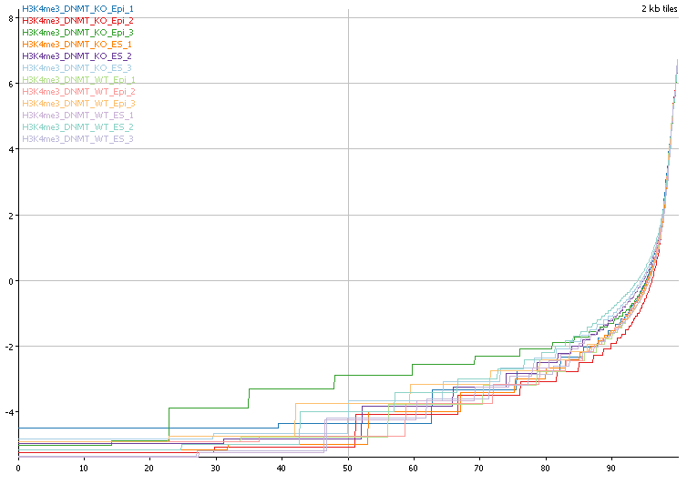

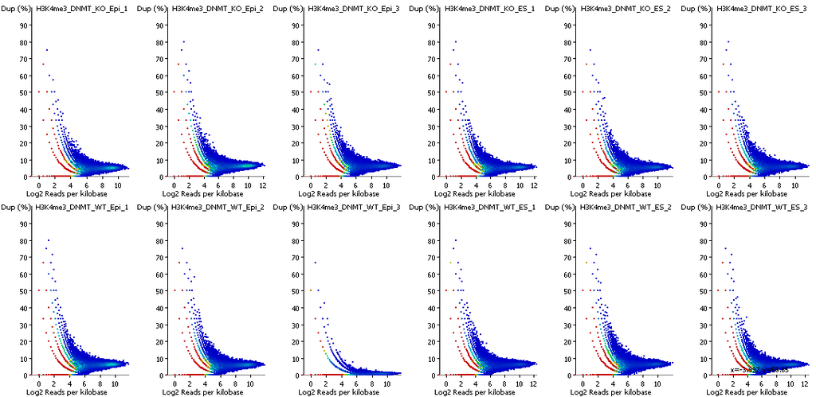

WT Epi 3 was the one that I downsampled.

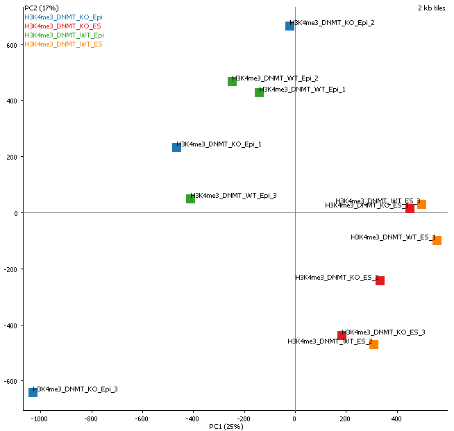

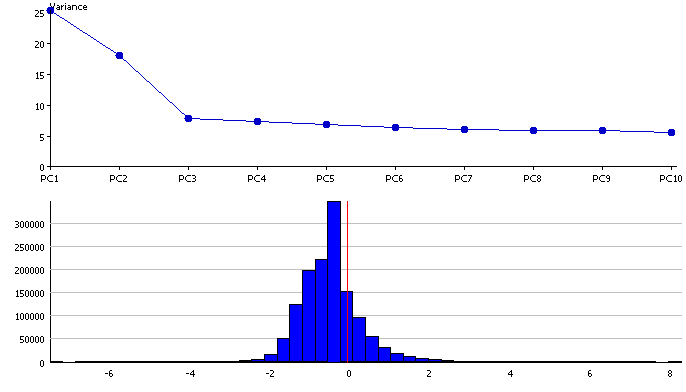

Separation ES / Epi

[figure not shown]